# Tutorial: Gráfico de coordenadas paralelas

Emmanuel Cristiano Lopes de Moraes

29/10/2019

```r
library("GGally")
library("hrbrthemes")
library("viridis")
library("dplyr")
```

```r
library("ggplot2")
library("png")
```

## Definição

Parallel plot ou gráfico de coordenadas paralelas permite comparar o recurso de várias observações individuais (series) em um conjunto de variáveis numéricas. Cada barra vertical representa uma variável e geralmente possui sua própria escala. (As unidades podem até ser diferentes). Os valores são plotados como séries de linhas conectadas em cada eixo.

## Íris

O ìris, conjunto de dados, fornece quatro recursos (cada um representado com uma linha vertical) para 150 amostras de flores (cada uma representada com uma linha de cores). As amostras são agrupadas em três espécies.

```r
data <- iris
head(data)
```

```
##   Sepal.Length Sepal.Width Petal.Length Petal.Width Species
## 1          5.1         3.5          1.4         0.2  setosa
## 2          4.9         3.0          1.4         0.2  setosa
## 3          4.7         3.2          1.3         0.2  setosa
## 4          4.6         3.1          1.5         0.2  setosa
## 5          5.0         3.6          1.4         0.2  setosa
## 6          5.4         3.9          1.7         0.4  setosa
```

```r
tail(data)
```

```
##     Sepal.Length Sepal.Width Petal.Length Petal.Width   Species
## 145          6.7         3.3          5.7         2.5 virginica
## 146          6.7         3.0          5.2         2.3 virginica
## 147          6.3         2.5          5.0         1.9 virginica
## 148          6.5         3.0          5.2         2.0 virginica
## 149          6.2         3.4          5.4         2.3 virginica
## 150          5.9         3.0          5.1         1.8 virginica
```

## Gráfico de Coordenadas paralelas (mais básico)

```r
require("ggplot2")
require("hrbrthemes")
require("GGally")
```

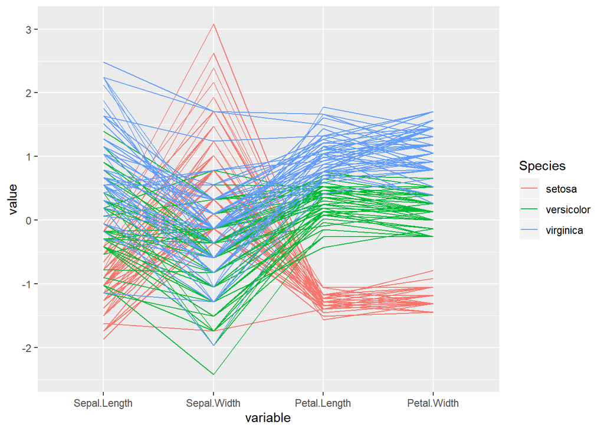

```r
# (1ª parte) mais simples
# Libraries
library(GGally)

# Data set is provided by R natively
data <- iris

# Plot
ggparcoord(data, columns = 1:4, groupColumn = 5)
```

## Parallel plot (Cor personalizada, tema, aparência geral)

O gráfico abaixo destaca eficientemente que setosa tem pétalas menores, mas sua sépala tende a ser mais larga.

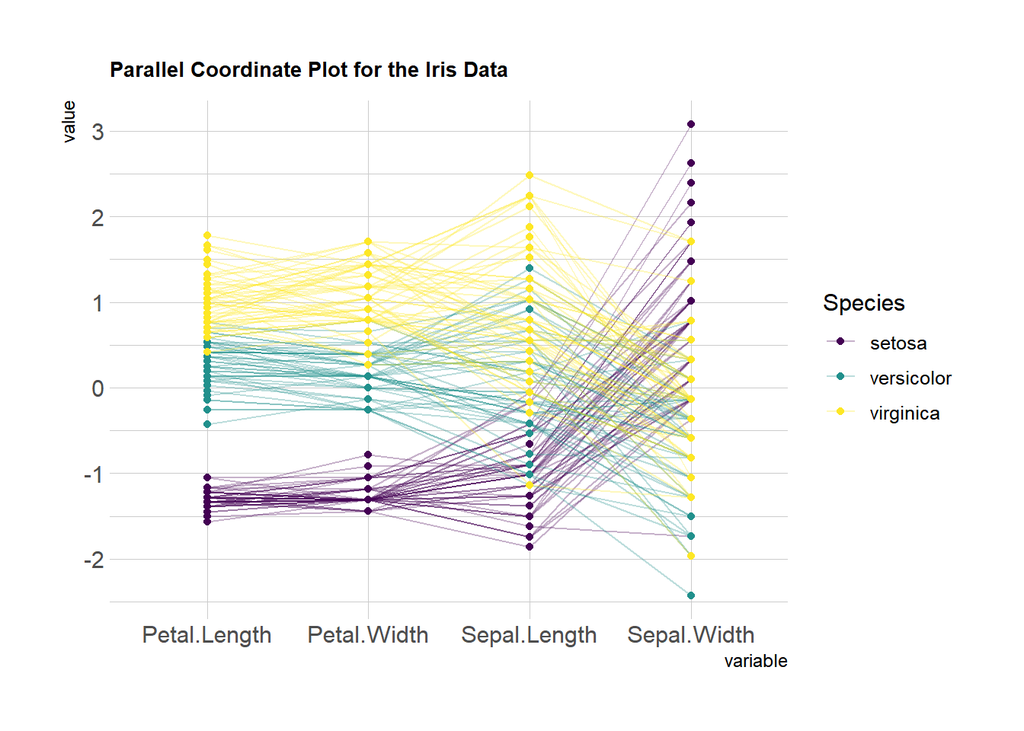

```r
# (2ª parte) Cor personalizada, tema, aparência geral
# Libraries
library(hrbrthemes)
library(GGally)
library(viridis)
library(viridisLite)

# Data set is provided by R natively
data <- iris

# Plot
ggparcoord(data,
           columns = 1:4, groupColumn = 5, order = "anyClass",
           showPoints = TRUE,
           title = "Parallel Coordinate Plot for the Iris Data",
           alphaLines = 0.3
) +
  scale_color_viridis(discrete=TRUE) +
  theme_ipsum()+
  theme(
    plot.title = element_text(size=10)
  )
```

## Parallel plot (Dimensionamento)

A escala transforma os dados brutos em uma nova escala comum a outras variáveis. É importante para comparar variáveis que não possuem a mesma unidade.

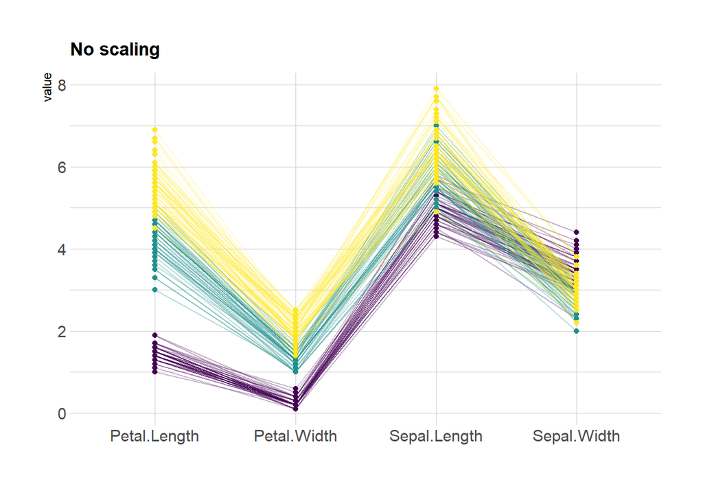

```r
# (3ª parte) Dimensionamento
# Libraries
library(hrbrthemes)
library(GGally)
library(viridis)
library(viridisLite)

ggparcoord(data,
           columns = 1:4, groupColumn = 5, order = "anyClass",
           scale="globalminmax",
           showPoints = TRUE,
           title = "No scaling",
           alphaLines = 0.3
) +
  scale_color_viridis(discrete=TRUE) +
  theme_ipsum()+
  theme(
    legend.position="none",
    plot.title = element_text(size=13)
  ) +
  xlab("")
```

## Parallel plot (Dimensionamento)

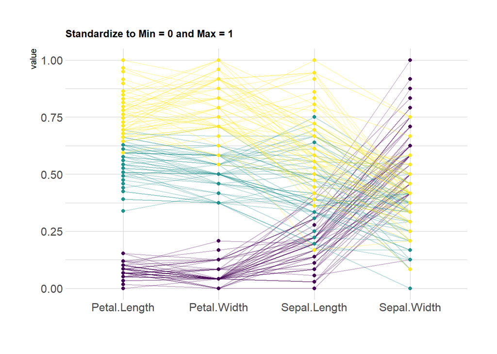

```r
# Libraries
library(hrbrthemes)
library(GGally)
library(viridis)
library(viridisLite)

ggparcoord(data,
    columns = 1:4, groupColumn = 5, order = "anyClass",
    scale="uniminmax",
    showPoints = TRUE,
    title = "Standardize to Min = 0 and Max = 1",
    alphaLines = 0.3
    ) +
  scale_color_viridis(discrete=TRUE) +
  theme_ipsum()+
  theme(
    legend.position="none",
    plot.title = element_text(size=10)
  ) +
  xlab("")
```

## Parallel plot (Dimensionamento)

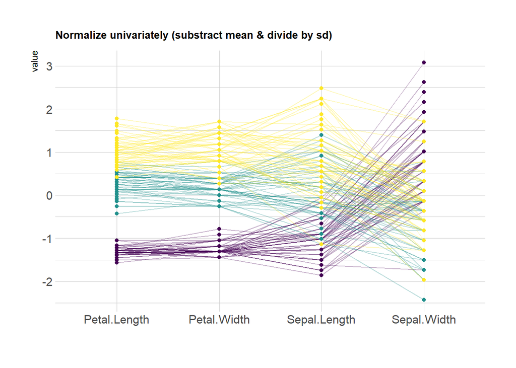

```r
# Libraries
library(hrbrthemes)
library(GGally)
library(viridis)
library(viridisLite)

ggparcoord(data,
    columns = 1:4, groupColumn = 5, order = "anyClass",
    scale="std",
    showPoints = TRUE,
    title = "Normalize univariately (substract mean & divide by sd)",
    alphaLines = 0.3
    ) +
  scale_color_viridis(discrete=TRUE) +
  theme_ipsum()+
  theme(
    legend.position="none",
    plot.title = element_text(size=10)
  ) +
  xlab("")
```

## Destacar um grupo (Setosa)

Destaque - um gráfico paralelo sendo um gráfico de linhas , a principal advertência é o gráfico de espaguete, onde muitas linhas se sobrepõem, tornando o gráfico ilegível. Existem várias soluções alternativas. Uma solução é destacar uma amostra específica ou um grupo de interesse específico:

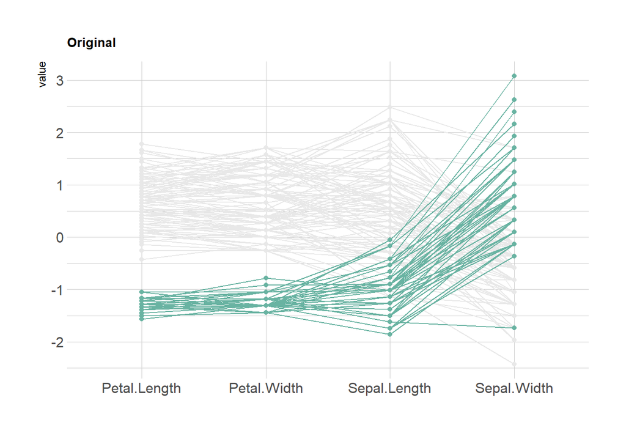

```r
# Libraries
library(GGally)
library(dplyr)

# Data set is provided by R natively
data <- iris

# Plot
data %>%
  arrange(desc(Species)) %>%
  ggparcoord(
    columns = 1:4, groupColumn = 5, order = "anyClass",
    showPoints = TRUE,
    title = "Original",
    alphaLines = 1
  ) +
  scale_color_manual(values=c( "#69b3a2", "#E8E8E8", "#E8E8E8") ) +
  theme_ipsum()+
  theme(
    legend.position="Default",
    plot.title = element_text(size=10)
  ) +
  xlab("")
```

## Referências

https://bookdown.org/yihui/rmarkdown/ioslides-presentation.html

http://cursos.leg.ufpr.br/prr/capDocDin.html

https://www.data-to-viz.com/graph/parallel.html#

https://www.r-graph-gallery.com/parallel-plot.html

http://sillasgonzaga.com/material/curso_visualizacao/apresentacao-de-dados-com-relatorios.html

http://www.leg.ufpr.br/~fernandomayer/palestra/useR-2015/Rmarkdown-rautu.html#links

http://material.curso-r.com/rbase/

https://translate.google.com.br/?hl=pt-BR&tab=rT&authuser=0